# Reproduceable Research Assignment

Damian Streets

28 July 2016

This assignment makes use of data from a personal activity monitoring device. This device collects data at 5 minute intervals through out the day. The data consists of two months of data from an anonymous individual collected during the months of October and November, 2012 and include the number of steps taken in 5 minute intervals each day.

[Data was sourced from Course Website](https://d396qusza40orc.cloudfront.net/repdata%2Fdata%2Factivity.zip)

## Loading and preprocessing the data

- Load Data from Working directory, and reformat the dates to YMD format.

```r
RawData <- read.csv("activity.csv")
RawData$date <- as.Date(RawData$date, "%Y-%m-%d")
head(RawData)
```

```
##   steps       date interval
## 1    NA 2012-10-01        0
## 2    NA 2012-10-01        5
## 3    NA 2012-10-01       10
## 4    NA 2012-10-01       15
## 5    NA 2012-10-01       20
## 6    NA 2012-10-01       25
```

## What is mean total number of steps taken per day?

Ignoring missing (NA) data  
* Calculate the total number of steps taken per day  
* Make a histogram of the total number of steps taken each day  
* Calculate and report the mean and median of the total number of steps taken per day

```r
TotalStepsPerDay <- aggregate(steps ~ date, data = RawData, sum, na.rm = TRUE)
head(TotalStepsPerDay)
```

```
##         date steps
## 1 2012-10-02   126
## 2 2012-10-03 11352
## 3 2012-10-04 12116
## 4 2012-10-05 13294
## 5 2012-10-06 15420
## 6 2012-10-07 11015
```

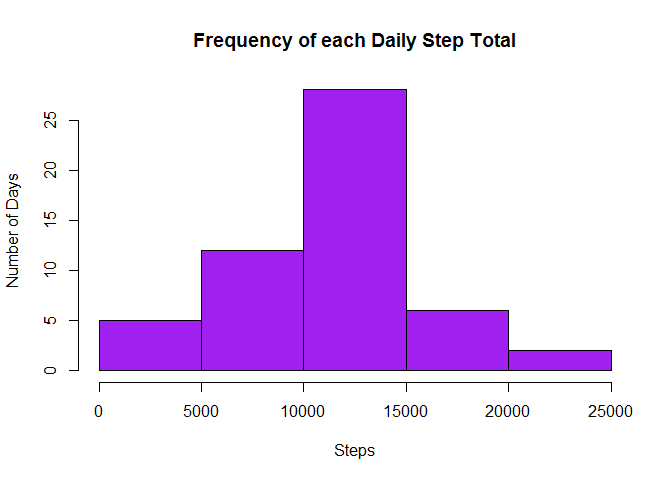

```r
hist(TotalStepsPerDay$steps, xlab="Steps", ylab="Number of Days", main="Frequency of each Daily Step Total", col="purple")
```

```r
a_val <- round(mean(TotalStepsPerDay$steps, na.rm = TRUE),2)
b_val <- round(median(TotalStepsPerDay$steps, na.rm = TRUE),2)
```

The **mean** number of Steps per Day (ignoring missing values) was 10766.19  
The **median** number of Steps per Day (ignoring missing values) was 10765

## What is the average daily activity pattern?

- Make a time series plot (i.e. type = “l”) of the 5-minute interval (x-axis) and the average number of steps taken, averaged across all days (y-axis)

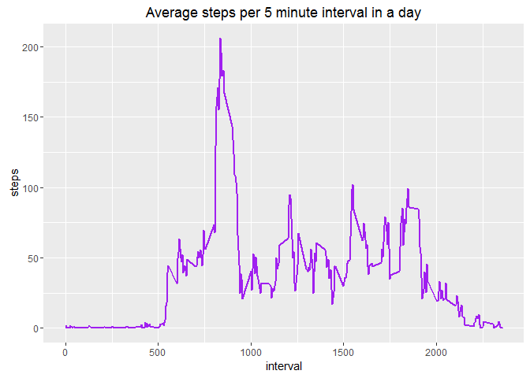

```r
AverageStepsPerInterval <- aggregate(steps ~ interval,data = RawData, mean, na.rm = TRUE)

g <- ggplot(AverageStepsPerInterval, mapping=aes(interval, steps)) + geom_line(colour="purple", size=1)
g + ggtitle("Average steps per 5 minute interval in a day")
```

- Which 5-minute interval, on average across all the days in the dataset, contains the maximum number of steps?

```r
max_row_id <- which.max(AverageStepsPerInterval$steps)

intv <- AverageStepsPerInterval[max_row_id, "interval"]
```

The **5 minute interval** with the maximum average Steps per Day (ignoring missing values) was 835